# Forecasting Solar Radiation

## 9.5 Residual Statistics

```r
# Mean of Residuals of Additive Model
mean(resid(hwAdd),na.rm = TRUE)
```

```
[1] -0.1435394
```

```r
# Normality of Residuals of Additive Model
shapiro.test(x = hwAdd$residuals)# Null: Normality
```

```
    Shapiro-Wilk normality test

data:  hwAdd$residuals
W = 0.88886, p-value < 2.2e-16
```

```r
# Mean of Residuals of Multiplicative Model
mean(resid(hwMult),na.rm = TRUE)
```

```
[1] 0.02493787
```

```r
# Normality of Residuals of Additive Model
shapiro.test(x = hwMult$residuals)# Null: Normality
```

```
    Shapiro-Wilk normality test

data:  hwMult$residuals
W = 0.3658, p-value < 2.2e-16
```

Both models have non normal residuals and the mean of residuals is almost zero for the multiplicative model but for the additive model -0.1 which may indicate bias in the fit.

## 9.6 Test Prediction

We apply the model on the test set and get accuracy measures.

```r
# Generate forecasts for Additive Model
hwAddFcast <- forecast(object = hwAdd,h = h,simulate = TRUE,bootstrap = TRUE)
# Generate forecasts for Multiplicative Model
hwMultFcast <- forecast(object = hwMult,h = h,simulate = TRUE,bootstrap = TRUE)
# Compare Accuracy of Additive Model With Test Set
hwAddTestAcc <- accuracy(f = hwAddFcast,x = solarTest)
hwAddTestAcc
```

```
                     ME     RMSE      MAE        MPE     MAPE      MASE
Training set -0.1435394 2.498745 1.610870  -2.420677 13.52726 0.2301965
Test set     -1.4721587 3.785931 2.638743 -14.953302 20.23272 0.3770814
                  ACF1 Theil's U
Training set 0.1893765        NA
Test set     0.8994513  1.036343
```

```r
# Compare Accuracy With Multiplicative Model Test Set
hwMultTestAcc <- accuracy(f = hwMultFcast,x = solarTest)
hwMultTestAcc
```

```
                      ME     RMSE      MAE       MPE     MAPE      MASE
Training set -0.09352173 2.191704 1.309591 -2.517529 10.79732 0.1871431
Test set     -0.30204028 3.500766 2.791901 -8.103540 19.38496 0.3989681
                     ACF1 Theil's U
Training set -0.005335593        NA
Test set      0.889322700 0.8954755
```

## 9.7 Forecast Plot

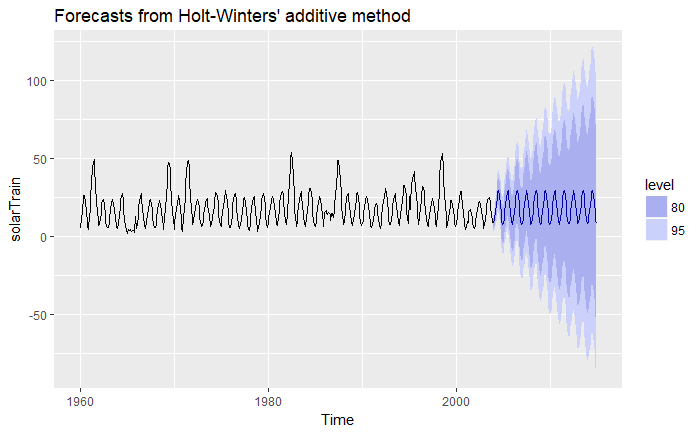

```r
# Plot of Additive Model
autoplot(object = hwAddFcast)
```

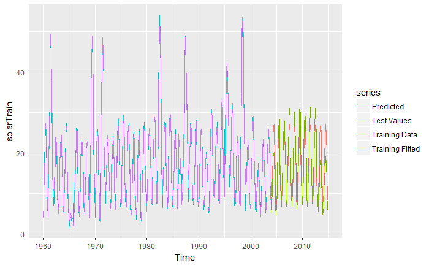

```r
# Plot of Multiplicative Model
autoplot(object = solarTrain,series = "Training Data") +
    autolayer(hwMult$fitted,series = "Training Fitted") +
    autolayer(hwMultFcast$mean,series = "Predicted") +
    autolayer(solarTest,series = "Test Values")
```

## 9.8 Observations

Adding the results to Results dataframe.

```r
# Update modelResults
#c("Model","TrainAcc.","TestAcc.","Res.Autocorr","Res.Variance","Res.Timeplot","Res.Mean","Res.Normality")#
# Additive Model Result
hwAddResult <- data.frame("HW Additive",0.23,0.377,"Present","Present","Pattern",-0.143,"Non Normality",stringsAsFactors = FALSE)
names(hwAddResult) <- c("Model","TrainAcc.","TestAcc.","Res.Autocorr","Res.Variance","Res.Timeplot","Res.Mean","Res.Normality")
# Multiplicative Model Result
hwMultResult <- data.frame("HW Multiplicative",0.187,0.398,"Present","Present","Pattern",0.024,"Non Normality",stringsAsFactors = FALSE)
names(hwMultResult) <- c("Model","TrainAcc.","TestAcc.","Res.Autocorr","Res.Variance","Res.Timeplot","Res.Mean","Res.Normality")
modelResults <- rbind(modelResults,hwAddResult,hwMultResult)
rm(hwAdd,hwMult,hwAddFcast,hwMultFcast,hwAddResult,hwMultResult,hwAddTestAcc,hwMultTestAcc)
```

# 10 **ETS Models**

The ETS Models are a group of models based on the Exponential Smoothing models of which Holt Winters is a part. The ETS models also model the error terms and provide different options for the optimization criterion for parameter estimation.

## 10.1 Model Fitting

```r
# ETS Model (Z,N,A)
etsZNA <- ets(y = solarTrain,model = 'ZNA')
# ETS Model (Z,N,M)
etsZNM <- ets(y = solarTrain,model = 'ZNM')
# Auto Ets
etsauto <- ets(y = solarTrain)
```

## 10.2 Plot of Model Fit

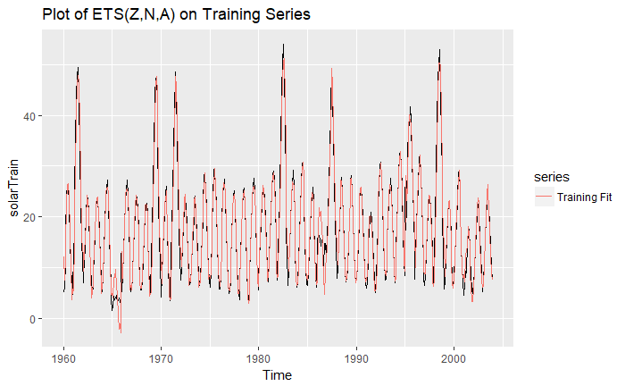

```r
# Plot of ETS(Z,N,A)
autoplot(solarTrain,fcol = NA,PI = FALSE) +
    autolayer(fitted(etsZNA),series = "Training Fit") +
 ggtitle("Plot of ETS(Z,N,A) on Training Series")
```

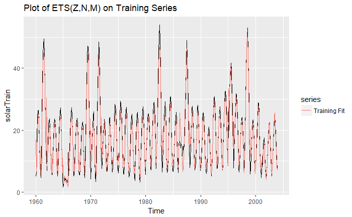

```r
# Plot of ETS(Z,N,M)
autoplot(solarTrain,fcol = NA,PI = FALSE) +
    autolayer(fitted(etsZNM),series = "Training Fit") +
 ggtitle("Plot of ETS(Z,N,M) on Training Series")
```

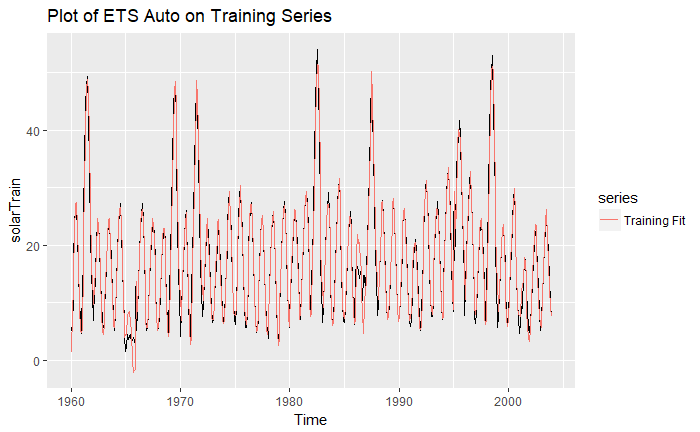

```r
# Plot of ETS()
autoplot(solarTrain,fcol = NA,PI = FALSE) +
    autolayer(fitted(etsauto),series = "Training Fit") +
 ggtitle("Plot of ETS Auto on Training Series")
```

## 10.3 Accuracy on Training Data

```r
# Accuracy of ETS(Z,N,A)
accuracy(f = etsZNA)# MASE 0.2366
```

```
                       ME     RMSE      MAE       MPE     MAPE      MASE
Training set -0.006301355 2.536733 1.655721 -2.126895 14.11349 0.2366057
                  ACF1
Training set 0.1913559
```

```r
# Accuracy of ETS(Z,N,M)
accuracy(f = etsZNM)# MASE 0.3267
```

```
                    ME     RMSE      MAE       MPE    MAPE      MASE
Training set 0.3919208 3.383854 2.286655 -5.916812 20.2172 0.3267674
                  ACF1
Training set 0.2817463
```

```r
# Accuracy of ETS Auto
accuracy(f = etsauto)# MASE 0.2227
```

```
                      ME     RMSE      MAE       MPE     MAPE      MASE
Training set 0.007964832 2.460185 1.565806 -1.408905 13.15062 0.2237567
                  ACF1
Training set 0.1531124
```

## 10.4 Residual Plots

Analyse the residuals plots of the Model Fit.

```
    Ljung-Box test

data:  Residuals from ETS(A,N,A)
Q* = 200.1, df = 10, p-value < 2.2e-16

Model df: 14.   Total lags used: 24
```

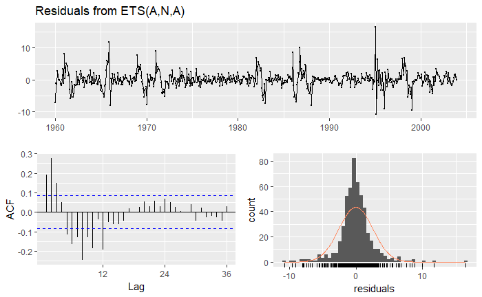

```r
# Residual Plots of ETS(Z,N,A) Model
checkresiduals(etsZNA)
```

```
    Ljung-Box test

data:  Residuals from ETS(M,N,M)
Q* = 91.317, df = 10, p-value = 2.887e-15

Model df: 14.   Total lags used: 24
```

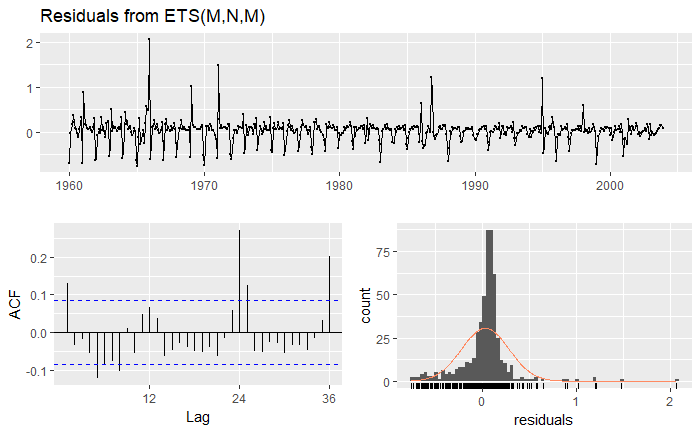

```r
# Residual Plots of ETS(Z,N,M) Model
checkresiduals(etsZNM)
```

```
    Ljung-Box test

data:  Residuals from ETS(A,Ad,A)
Q* = 172.64, df = 7, p-value < 2.2e-16

Model df: 17.   Total lags used: 24
```

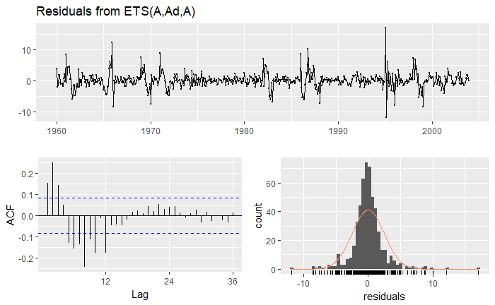

```r
# Residual Plots of ETS Auto Model
checkresiduals(etsauto)
```

## 10.5 Residual Statistics

```r
# Mean and Normality of Residuals of ETS(Z,N,A)
mean(resid(etsZNA),na.rm = TRUE);shapiro.test(x = resid(etsZNA))
```

```
[1] -0.006301355

    Shapiro-Wilk normality test

data:  resid(etsZNA)
W = 0.90139, p-value < 2.2e-16
```

```r
# Mean and Normality of Residuals of ETS(Z,N,M)
mean(resid(etsZNM),na.rm = TRUE);shapiro.test(x = resid(etsZNM))
```

```
[1] 0.02563535

    Shapiro-Wilk normality test

data:  resid(etsZNM)
W = 0.79246, p-value < 2.2e-16
```

```r
# Mean and Normality of Residuals of ETS Auto
mean(resid(etsauto),na.rm = TRUE);shapiro.test(x = resid(etsauto))
```

```
[1] 0.007964832

    Shapiro-Wilk normality test

data:  resid(etsauto)
W = 0.8817, p-value < 2.2e-16
```

## 10.6 Test Prediction

We apply the model on the test set and get accuracy measures.

```r
# Generate forecasts for ETS(Z,N,A) Model
etsZNAFcast <- forecast(object = etsZNA,h = h,simulate = TRUE,bootstrap = TRUE)
# Generate forecasts for ETS(Z,N,M) Model
etsZNMFcast <- forecast(object = etsZNM,h = h,simulate = TRUE,bootstrap = TRUE)
# Generate forecasts for ETS Auto Model
etsAutoFcast <- forecast(object = etsauto,h = h,simulate = TRUE,bootstrap = TRUE)
# Compare Accuracy of ETS(Z,N,A)
etsZNATestAcc <- accuracy(f = etsZNAFcast,x = solarTest)
etsZNATestAcc
```

```
                       ME     RMSE      MAE        MPE     MAPE      MASE
Training set -0.006301355 2.536733 1.655721  -2.126895 14.11349 0.2366057
Test set     -1.526287141 3.793348 2.636685 -14.768241 19.92244 0.3767873
                  ACF1 Theil's U
Training set 0.1913559        NA
Test set     0.8910968  1.044685
```

```r
# Compare Accuracy of ETS(Z,N,M)
etsZNMTestAcc <- accuracy(f = etsZNMFcast,x = solarTest)
etsZNMTestAcc
```

```
                     ME     RMSE      MAE        MPE     MAPE      MASE
Training set  0.3919208 3.383854 2.286655  -5.916812 20.21720 0.3267674
Test set     -5.8758768 7.697715 5.913800 -38.014689 38.39193 0.8450935
                  ACF1 Theil's U
Training set 0.2817463        NA
Test set     0.8684003  1.940096
```

```r
# Compare Accuracy of ETS Auto
etsAutoTestAcc <- accuracy(f = etsAutoFcast,x = solarTest)
etsAutoTestAcc
```

```
                       ME     RMSE      MAE        MPE     MAPE      MASE
Training set  0.007964832 2.460185 1.565806  -1.408905 13.15062 0.2237567
Test set     -1.604026423 3.807692 2.624425 -15.244342 19.95740 0.3750354
                  ACF1 Theil's U
Training set 0.1531124        NA
Test set     0.8977629  1.050822
```

## 10.7 Forecast Plot

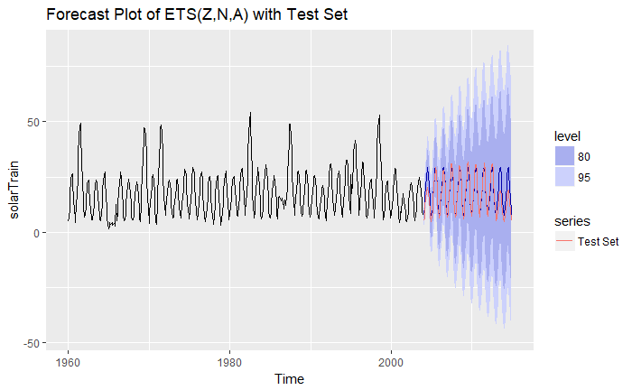

```r
# Plot of ETS(Z,N,A)
autoplot(object = etsZNAFcast) +
    autolayer(solarTest,series = "Test Set") +
    ggtitle("Forecast Plot of ETS(Z,N,A) with Test Set")
```

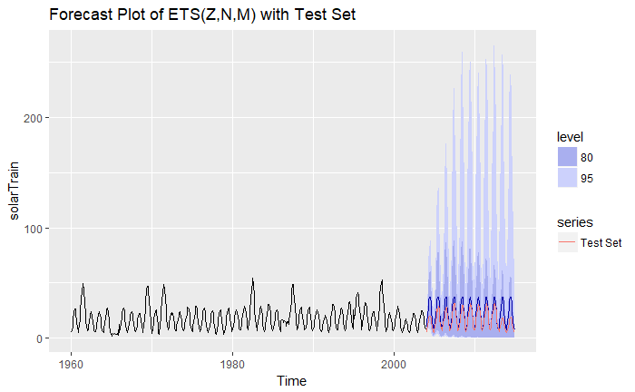

```r
# Plot of ETS(Z,N,M)
autoplot(object = etsZNMFcast) +
    autolayer(solarTest,series = "Test Set") +
    ggtitle("Forecast Plot of ETS(Z,N,M) with Test Set")
```

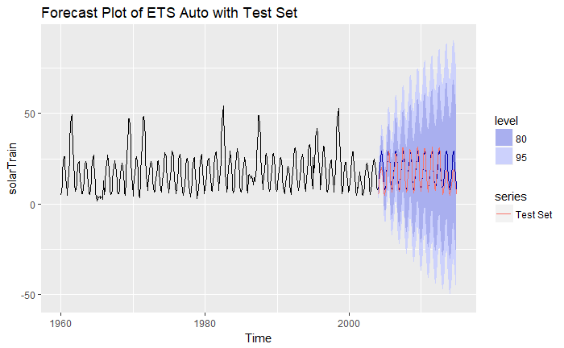

```r
# Plot of ETS Auto
autoplot(object = etsAutoFcast) +
    autolayer(solarTest,series = "Test Set") +
    ggtitle("Forecast Plot of ETS Auto with Test Set")
```

## 10.8 Observations

Adding the results to Results dataframe.

```r
# Update modelResults
#c("Model","TrainAcc.","TestAcc.","Res.Autocorr","Res.Variance","Res.Timeplot","Res.Mean","Res.Normality")#
# ETS(Z,N,A)
etsZNAResult <- data.frame("ETS(Z,N,A)",0.2366,0.3767,"Present","Present","Pattern",-0.006,"Non Normality",stringsAsFactors = FALSE)
names(etsZNAResult) <-c("Model","TrainAcc.","TestAcc.","Res.Autocorr","Res.Variance","Res.Timeplot","Res.Mean","Res.Normality")
# ETS(Z,N,M)
etsZNMResult <- data.frame("ETS(Z,N,M)",0.3267,0.8450,"Present","Present","Pattern",0.025,"Non Normality",stringsAsFactors = FALSE)
names(etsZNMResult) <-c("Model","TrainAcc.","TestAcc.","Res.Autocorr","Res.Variance","Res.Timeplot","Res.Mean","Res.Normality")
# ETS Auto
etsAutoResult <- data.frame("ETS Auto",0.2237,0.3750,"Present","Present","Pattern",0.007,"Non Normality",stringsAsFactors = FALSE)
names(etsAutoResult) <-c("Model","TrainAcc.","TestAcc.","Res.Autocorr","Res.Variance","Res.Timeplot","Res.Mean","Res.Normality")
modelResults <- rbind(modelResults,etsZNAResult,etsZNMResult,etsAutoResult)
rm(etsZNA,etsZNM,etsauto,etsZNAFcast,etsZNMFcast,etsAutoFcast,etsZNAResult,etsZNMResult,etsAutoResult,etsZNATestAcc,etsZNMTestAcc,etsAutoTestAcc)
```

# 11 **ARIMA**

A no of ARIMA Models were fit with different values of AR and MA for the seasonal characteristics. The best model is demonstrated here.

## 11.1 Model Fitting

```r
# ARIMA Model
Arima <- Arima(y = solarTrain,order = c(3,0,2),seasonal = c(1,1,1))
summary(Arima)
```

```
Series: solarTrain
ARIMA(3,0,2)(1,1,1)[12]

Coefficients:
         ar1      ar2     ar3      ma1     ma2     sar1     sma1
      2.1785  -1.7501  0.5207  -1.1533  0.6910  -0.1667  -0.9702
s.e.  0.1266   0.2337  0.1173   0.1110  0.0834   0.0564   0.0389

sigma^2 estimated as 4.917:  log likelihood=-1159.04
AIC=2334.08   AICc=2334.37   BIC=2368.05

Training set error measures:
                     ME     RMSE      MAE       MPE     MAPE      MASE
Training set 0.05395142 2.177221 1.420674 -2.634651 11.80047 0.2030171
                     ACF1
Training set -0.005893674
```

## 11.2 Plot of Model Fit

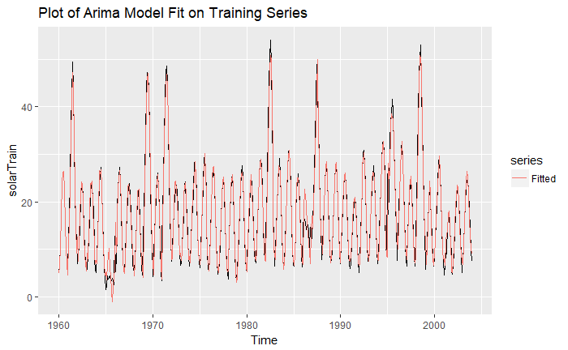

```r
# Plot of Model Fit on Train Data
autoplot(solarTrain,fcol = NA,PI = FALSE) +
    autolayer(Arima$fitted,series = "Fitted") +
    ggtitle("Plot of Arima Model Fit on Training Series")
```

## 11.3 Accuracy on Training Data

```r
# Accuracy on Training Set for Train Data
accuracy(f = Arima)# MASE 0.2030
```

```
                     ME     RMSE      MAE       MPE     MAPE      MASE
Training set 0.05395142 2.177221 1.420674 -2.634651 11.80047 0.2030171
                     ACF1
Training set -0.005893674
```

## 11.4 Residual Plots

Analyse the residuals plots of the Model Fit.

```
    Ljung-Box test

data:  Residuals from ARIMA(3,0,2)(1,1,1)[12]
Q* = 16.513, df = 17, p-value = 0.4878

Model df: 7.   Total lags used: 24
```

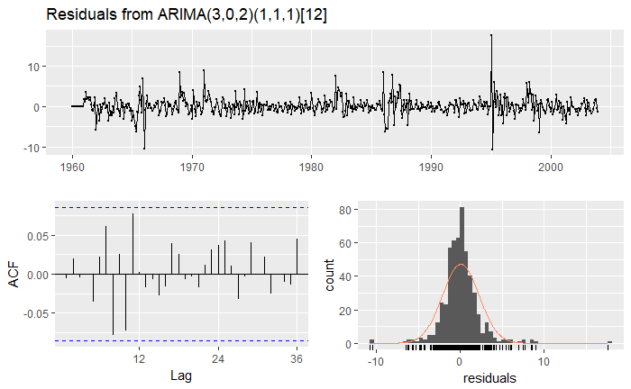

```r
# Residual Plots of Train Data
checkresiduals(Arima)# No AutoCorr and No Pattern
```

## 11.5 Residual Statistics

```r
# Mean of Residuals of Train Data
mean(resid(Arima),na.rm = TRUE) # 0.0539
```

```
[1] 0.05395142
```

```r
# Normality of Residuals of Train Data
shapiro.test(x = Arima$residuals)# Null: Normality # Non normal
```

```
    Shapiro-Wilk normality test

data:  Arima$residuals
W = 0.87754, p-value < 2.2e-16
```

## 11.6 Test Prediction

We apply the model on the test set and get accuracy measures.

```r
# Generate forecasts
ArimaFcast <- forecast(object = Arima,h = h)
# Compare Accuracy With Test Set
ArimaTestAcc <- accuracy(f = ArimaFcast,x = solarTest)
ArimaTestAcc
```

```
                      ME     RMSE      MAE        MPE     MAPE      MASE
Training set  0.05395142 2.177221 1.420674  -2.634651 11.80047 0.2030171
Test set     -1.30499487 3.691279 2.611606 -13.466548 19.56148 0.3732035
                     ACF1 Theil's U
Training set -0.005893674        NA
Test set      0.896156622  1.009999
```

Mase Value on Test Set of 0.3732

## 11.7 Forecast Plot

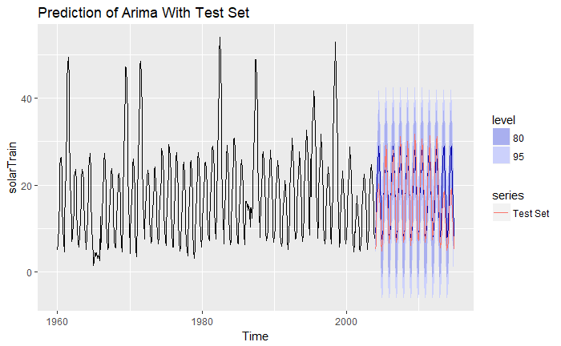

```r
autoplot(object = ArimaFcast)+
    autolayer(solarTest,series = "Test Set") +
    ggtitle("Prediction of Arima With Test Set")
```

## 11.8 Observations

Adding the results to Results dataframe.

```r
# Update modelResults
#c("Model","TrainAcc.","TestAcc.","Res.Autocorr","Res.Variance","Res.Timeplot","Res.Mean","Res.Normality")#
# Train Data Results
ArimaResult <- data.frame(" Arima",0.2030,0.3732,"Not Present","Present","No Pattern",0.053,"Non Normality",stringsAsFactors = FALSE)
names(ArimaResult) <- c("Model","TrainAcc.","TestAcc.","Res.Autocorr","Res.Variance","Res.Timeplot","Res.Mean","Res.Normality")
modelResults <- rbind(modelResults,ArimaResult)
rm(Arima,ArimaFcast,ArimaResult,ArimaTestAcc)
```

# 12 Final Model

Different models were fit which gave different MASE values and different residuals. The best models in terms of MASE on Test Set are given below:

```r
#Sort Models on MASE on Test Set
modelResults %>% arrange(TestAcc.)
```

| Model | TrainAcc. | TestAcc. | Res.Autocorr | Res.Variance | Res.Timeplot | Res.Mean | Res.Normality |
| --- | --- | --- | --- | --- | --- | --- | --- |
| Linear Model | 0.5615 | 0.3700 | Present | Present | Pattern | 2.414e-16 | Non Normality |
| Arima | 0.2030 | 0.3732 | Not Present | Present | No Pattern | 5.300e-02 | Non Normality |
| ETS Auto | 0.2237 | 0.3750 | Present | Present | Pattern | 7.000e-03 | Non Normality |
| ETS(Z,N,A) | 0.2366 | 0.3767 | Present | Present | Pattern | -6.000e-03 | Non Normality |
| HW Additive | 0.2300 | 0.3770 | Present | Present | Pattern | -1.430e-01 | Non Normality |
| STL Model | 0.2170 | 0.3800 | Present | Present | Pattern | 6.160e-03 | Non Normality |
| HW Multiplicative | 0.1870 | 0.3980 | Present | Present | Pattern | 2.400e-02 | Non Normality |
| Seasonal Naive | 1.0000 | 0.4240 | Present | Present | Pattern | 4.500e-02 | Non Normality |
| ETS(Z,N,M) | 0.3267 | 0.8450 | Present | Present | Pattern | 2.500e-02 | Non Normality |

The best two models were the Linear Model and Arima Model in terms of MASE on test set. We select the ARIMA Model as the best model because it has good residuals in terms of autocorrelation even though its accuracy on test set is marginally worse (0.003).

We can deal with the non normality in ARIMA model by generating prediction intervals using bootstrap method. The mean of the ARIMA model residuals is 0.053, which means the forecasts are slightly biased. We can deal with this by adding the mean of residuals to the forecasts.

We do the following below:

Creating the Model

```r
# Model Fit
Arima <- Arima(y = solarTrain,order = c(3,0,2),seasonal = c(1,1,1))
# Summary of Model
summary(Arima)
```

```
Series: solarTrain
ARIMA(3,0,2)(1,1,1)[12]

Coefficients:
         ar1      ar2     ar3      ma1     ma2     sar1     sma1
      2.1785  -1.7501  0.5207  -1.1533  0.6910  -0.1667  -0.9702
s.e.  0.1266   0.2337  0.1173   0.1110  0.0834   0.0564   0.0389

sigma^2 estimated as 4.917:  log likelihood=-1159.04
AIC=2334.08   AICc=2334.37   BIC=2368.05

Training set error measures:
                     ME     RMSE      MAE       MPE     MAPE      MASE
Training set 0.05395142 2.177221 1.420674 -2.634651 11.80047 0.2030171
                     ACF1
Training set -0.005893674
```

```r
# Residual Mean
m <- mean(Arima$residuals) # mean of residuals is 0.053
```

We deal with the non normality by using bootstrap prediction intervals and deal with the mean by adding the mean to the forecasts.

```r
# Model Prediction
ArimaFcast <- forecast(object = Arima,h = h,bootstrap = TRUE)
# Adding the mean to the forecasts
ArimaFcast$mean <- ArimaFcast$mean + m
# Accuracy on Test Data with mean addition
accuracy(f = ArimaFcast,x = solarTest) # MASE 0.3740
```

```
                      ME     RMSE      MAE        MPE     MAPE      MASE
Training set  0.05395142 2.177221 1.420674  -2.634651 11.80047 0.2030171
Test set     -1.35894629 3.710696 2.617328 -13.888127 19.71847 0.3740212
                     ACF1 Theil's U
Training set -0.005893674        NA
Test set      0.896156622  1.019035
```

The plot of the forecasts is as follows:

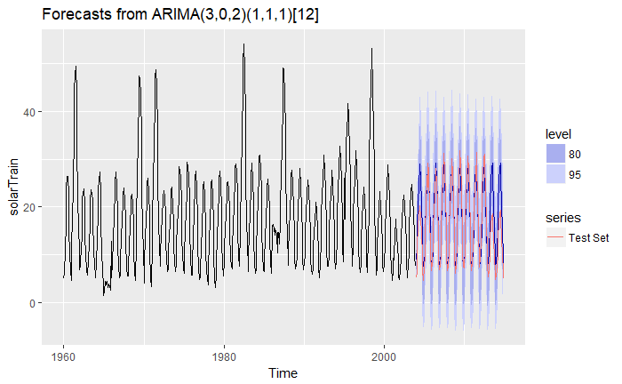

```r
# Plot of Forecasts
autoplot(ArimaFcast,series = "Forecast") +
    autolayer(object = solarTest,series = "Test Set")
```

With mean addition the MASE slightly increases to 0.374 from 0.3732. We still go ahead with this model since the change is negligible and residuals are good. From the models explored the best model was ARIMA(3,0,2)(1,1,1)[12].